# **Model Hyperparameter Tuning**

> **Notebook Author:** Brian Keith (bkeith9@gatech.edu)  
> **Purpose:** This notebook takes in the results of all the basis models that were generated and performs hyperparameter tuning to the dataset that generated the best model. Due to the runtime of the notebook, the results are offloaded for further analysis in later notebooks.

> **Data Citation:**
> - Andreas Miltiadous and Katerina D. Tzimourta and Theodora Afrantou and Panagiotis Ioannidis and Nikolaos Grigoriadis and Dimitrios G. Tsalikakis and Pantelis Angelidis and Markos G. Tsipouras and Evripidis Glavas and Nikolaos Giannakeas and Alexandros T. Tzallas (2023). A dataset of EEG recordings from: Alzheimer's disease, Frontotemporal dementia and Healthy subjects. OpenNeuro. [Dataset] doi: doi:10.18112/openneuro.ds004504.v1.0.6

> **Data Source:**
> - Dataset download as a zip file from: https://nemar.org/dataexplorer/detail?dataset_id=ds004504

> **Data Information:**
> - Cognitive and neuropsychological state was evaluated by the international Mini-Mental State Examination (**MMSE**)
>   - The MMSE score ranges from 0 to 30, with *a lower MMSE indicating more severe cognitive decline*.
> - Recordings include the EEG signal from 19 scalp electrodes `Fp1`, `Fp2`, `F7`, `F3`, `Fz`, `F4`, `F8`, `T3`, `C3`, `Cz`, `C4`, `T4`, `T5`, `P3`, `Pz`, `P4`, `T6`, `O1`, & `O2`, and 2 reference electrodes, placed according to the 10–20 international system (`A1` & `A2`).
>   - Sampling Rate = 500 Hz
>   - Resolution = 10 uV/mm
>   - Each recording lasted approximately 13.5 min for the AD group (min = 5.1, max = 21.3), 12 min for the FTD group (min = 7.9, max = 16.9), and 13.8 min for the CN group (min = 12.5, max = 16.5).
>     - In total, 485.5 min of AD, 276.5 min of FTD, and 402 min of CN recordings were collected and are included in the dataset.
> - 88 participants total
>   - Alzheimer’s disease (**AD**) patients (n=36)
>     - `Group = A`
>   - Frontotemporal dementia (**FTD**) patients (n=23)
>     - `Group = F`
>   - Healthy controls (**CN**) participants (n=29)
>     - `Group = C`

# Initial Tasks

## Set Params & Load Necessary Libraries

```python
SEED_VAL = 903027850 #GTID

#! KEY! Sets the max number of parameters that will be allowed to be tested.
MAX_PARAMS = 100
NFOLDS = 5

PALETTE = [
    '#66829a',
    '#003057',
    '#a9abac',
    '#54585A',
    '#BFB37C',
    '#857437',
]
PALETTE_CMAP = [
    '#66829a',
    # '#003057',
    '#a9abac',
    # '#54585A',
    '#BFB37C',
    # '#857437',
]
PALETTE_TRI = [
    '#003057',
    '#857437',
    '#54585A',
]

PARTICIPANT_CLASS_MAP = {
    'A': 'AtRisk',
    'C': 'Healthy',
    'F': 'AtRisk',
}

MODEL_ALIAS = {
    'RF': 'Random Forest',
    'XGB': 'XGBoost',
    'LR': 'Logistic Regression',
    'KNN': 'K-Nearest Neighbors',
    # 'GB': 'Gradient Boosting',
    # 'SVC': 'Support Vector Classifier',
}

#general
import pathlib
import pandas as pd
import numpy as np
import pickle
import matplotlib.pyplot as plt
from matplotlib.colors import LinearSegmentedColormap, hex2color
from math import ceil
from timeit import default_timer
import gc
import seaborn as sns
import matplotlib.pyplot as plt
import matplotlib.ticker as mtick

pd.set_option('display.max_columns', 500)
pd.set_option('display.max_colwidth', None)
pd.set_option('display.max_rows', 200)
plt.rcParams["font.family"] = "Georgia"

import warnings
warnings.simplefilter(action='ignore', category=FutureWarning)
warnings.simplefilter(action='ignore', category=UserWarning)

#custom modules
from helpers.utils import printmd, export_code,format_timing
from helpers.model_funcs import add_labels, score_model, generate_heatmap

#modeling
from sklearn.preprocessing import LabelEncoder
label_encoder = LabelEncoder()
from sklearn.ensemble import RandomForestClassifier#, GradientBoostingClassifier
from sklearn.linear_model import LogisticRegression
from sklearn.neighbors import KNeighborsClassifier
#from sklearn.svm import SVC
from multiprocessing import cpu_count
from xgboost import XGBClassifier

from sklearn.model_selection import KFold
from itertools import product

gt_cmap = LinearSegmentedColormap.from_list("custom_cmap", [hex2color(color) for color in PALETTE_CMAP])
```

## Read in Epochs

```python
epoch_file = 'data/EpochData.pkl'
data_file = 'data/ConsolidatedParticipantData.pkl'

with open(data_file, 'rb') as f:
    data_dict = pickle.load(f)

participants = data_dict['participants']
participants['Class'] = participants.Group.map(PARTICIPANT_CLASS_MAP)
del data_dict
gc.collect() # delete rest of data which is not needed

with open(epoch_file, 'rb') as f:
    epochs = pickle.load(f)

printmd('# <b><u>Data Summary</u></b>')
printmd(f'## <u>Participant Data Sample Preview:</u>')
print('Number of participants:', len(participants))
for i in participants.Group.unique():
    print(f'# of participants in Group {i}:', len(participants[participants.Group == i]))
for i in participants.Class.unique():
    print(f'# of participants in Class {i}:', len(participants[participants.Class == i]))
display(participants.sample(5, random_state=SEED_VAL))
participants.info()

printmd(f'## <u>Epoch Data Sample Preview:</u>')
print('Number of epoch datasets:', len(epochs))
print('Epoch dataset keys:')
print('|'.join(list(epochs.keys())))
printmd(f'### <u>Epoch Data (2000ms segments, 25 percent overlap) Sample Preview:</u>')
prev_epoch = epochs['2000_25']
display(prev_epoch.sample(5, random_state=SEED_VAL))
```

**Data Summary**

Participant Data Sample Preview:

```
Number of participants: 88
# of participants in Group A: 36
# of participants in Group C: 29
# of participants in Group F: 23
# of participants in Class AtRisk: 59
# of participants in Class Healthy: 29
```

|  | participant_id | Gender | Age | Group | MMSE | Class |
| --- | --- | --- | --- | --- | --- | --- |
| 20 | sub-021 | M | 79 | A | 22 | AtRisk |
| 47 | sub-048 | M | 65 | C | 30 | Healthy |
| 23 | sub-024 | F | 69 | A | 20 | AtRisk |
| 38 | sub-039 | M | 70 | C | 30 | Healthy |
| 50 | sub-051 | F | 75 | C | 30 | Healthy |

```
<class 'pandas.core.frame.DataFrame'>
RangeIndex: 88 entries, 0 to 87
Data columns (total 6 columns):
 #   Column          Non-Null Count  Dtype
---  ------          --------------  -----
 0   participant_id  88 non-null     object
 1   Gender          88 non-null     object
 2   Age             88 non-null     int64
 3   Group           88 non-null     object
 4   MMSE            88 non-null     int64
 5   Class           88 non-null     object
dtypes: int64(2), object(4)
memory usage: 4.3+ KB
```

Epoch Data Sample Preview:

```
Number of epoch datasets: 15
Epoch dataset keys:
2000_25|2000_50|2000_75|3000_25|3000_50|3000_75|4000_25|4000_50|4000_75|5000_25|5000_50|5000_75|6000_25|6000_50|6000_75
```

Epoch Data (2000ms segments, 25 percent overlap) Sample Preview:

|  | participant_id | seg_start | seg_end | Fp1_delta_psd | Fp1_delta_rbp | Fp1_theta_psd | Fp1_theta_rbp | Fp1_alpha_psd | Fp1_alpha_rbp | Fp1_beta_psd | Fp1_beta_rbp | Fp1_gamma_psd | Fp1_gamma_rbp | Fp2_delta_psd | Fp2_delta_rbp | Fp2_theta_psd | Fp2_theta_rbp | Fp2_alpha_psd | Fp2_alpha_rbp | Fp2_beta_psd | Fp2_beta_rbp | Fp2_gamma_psd | Fp2_gamma_rbp | F3_delta_psd | F3_delta_rbp | F3_theta_psd | F3_theta_rbp | F3_alpha_psd | F3_alpha_rbp | … |
| --- | --- | --- | --- | --- | --- | --- | --- | --- | --- | --- | --- | --- | --- | --- | --- | --- | --- | --- | --- | --- | --- | --- | --- | --- | --- | --- | --- | --- | --- | --- |
| 29127 | sub-054 | 180000 | 182000 | 101.619217 | 0.674185 | 24.120581 | 0.160026 | 13.992456 | 0.092832 | 7.909776 | 0.052477 | 3.087018 | 0.020481 | 106.206696 | 0.650375 | 25.143023 | 0.153968 | 15.774080 | 0.096595 | 9.856347 | 0.060357 | 6.320441 | 0.038704 | 94.978004 | 0.720623 | 16.586493 | 0.125846 | 10.386333 | 0.078804 | … |
| 37674 | sub-071 | 334500 | 336500 | 208.194153 | 0.868092 | 8.224080 | 0.034291 | 10.012435 | 0.041748 | 6.840643 | 0.028523 | 6.558210 | 0.027345 | 188.389313 | 0.847069 | 7.845501 | 0.035276 | 11.558975 | 0.051973 | 8.106111 | 0.036448 | 6.501420 | 0.029233 | 176.562836 | 0.882679 | 5.772325 | 0.028857 | 6.495738 | 0.032474 | … |
| 31740 | sub-059 | 99000 | 101000 | 171.904236 | 0.777076 | 16.911163 | 0.076445 | 4.141192 | 0.018720 | 13.030823 | 0.058905 | 15.231906 | 0.068854 | 167.716553 | 0.860897 | 17.136440 | 0.087962 | 3.610833 | 0.018535 | 3.923037 | 0.020137 | 2.429207 | 0.012469 | 166.697937 | 0.819073 | 21.829603 | 0.107260 | 3.687773 | 0.018120 | … |
| 7391 | sub-015 | 355500 | 357500 | 85.765564 | 0.729429 | 15.854277 | 0.134839 | 8.363755 | 0.071133 | 5.647585 | 0.048032 | 1.947914 | 0.016567 | 86.094177 | 0.704240 | 16.511936 | 0.135066 | 7.984750 | 0.065314 | 7.179772 | 0.058730 | 4.480576 | 0.036651 | 86.361984 | 0.729849 | 15.393760 | 0.130093 | 7.591955 | 0.064160 | … |
| 32704 | sub-061 | 9000 | 11000 | 105.474251 | 0.792686 | 9.439982 | 0.070946 | 3.943952 | 0.029641 | 7.605094 | 0.057156 | 6.596087 | 0.049573 | 115.901573 | 0.808774 | 8.561015 | 0.059740 | 4.359247 | 0.030419 | 7.668569 | 0.053512 | 6.814870 | 0.047555 | 101.144485 | 0.848470 | 6.448260 | 0.054092 | 2.684965 | 0.022523 | … |

## Read in Basis Model Results

```python
basis_results_file = 'data/BasisModelResults.pkl'

with open(basis_results_file, 'rb') as f:
    results = pickle.load(f)

results.keys()
```

```
dict_keys(['RF', 'XGB', 'LR', 'KNN'])
```

# Find Best Dataset for each Model

## Results for Each Model

**Model Results Summary**

|  | Dataset | Accuracy_Group_RF | Accuracy_Group_XGB | Accuracy_Group_LR | Accuracy_Group_KNN |
| --- | --- | --- | --- | --- | --- |
| 0 | 2000_25 | 0.852273 | 0.988636 | 0.761364 | 0.943182 |
| 1 | 2000_50 | 0.875000 | 0.988636 | 0.784091 | 0.931818 |
| 2 | 2000_75 | 0.931818 | 0.988636 | 0.761364 | 0.954545 |
| 3 | 3000_25 | 0.886364 | 0.988636 | 0.806818 | 0.954545 |
| 4 | 3000_50 | 0.909091 | 0.988636 | 0.784091 | 0.965909 |
| 5 | 3000_75 | 0.965909 | 0.988636 | 0.795455 | 0.977273 |
| 6 | 4000_25 | 0.909091 | 0.988636 | 0.829545 | 0.977273 |
| 7 | 4000_50 | 0.931818 | 0.988636 | 0.806818 | 0.988636 |
| 8 | 4000_75 | 0.977273 | 1.000000 | 0.806818 | 0.988636 |
| 9 | 5000_25 | 0.965909 | 1.000000 | 0.818182 | 0.977273 |
| 10 | 5000_50 | 0.943182 | 1.000000 | 0.863636 | 0.965909 |
| 11 | 5000_75 | 0.988636 | 1.000000 | 0.840909 | 0.988636 |
| 12 | 6000_25 | 0.931818 | 1.000000 | 0.852273 | 0.977273 |
| 13 | 6000_50 | 0.977273 | 1.000000 | 0.840909 | 0.988636 |
| 14 | 6000_75 | 0.988636 | 1.000000 | 0.840909 | 1.000000 |

**Model Results Visualization**

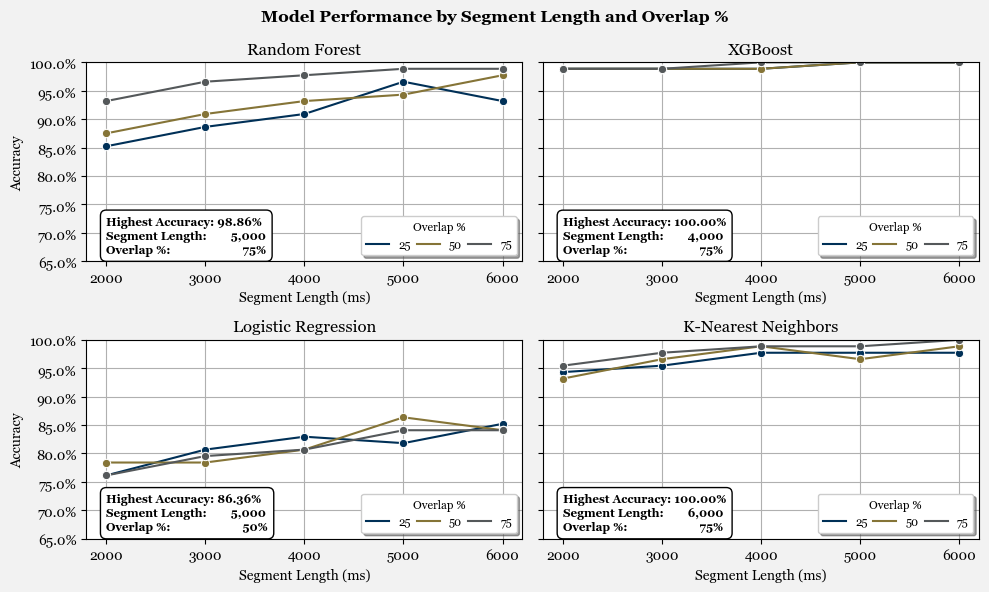

```python
results_rf = results['RF'].copy()
results_lr = results['LR'].copy()
results_xgb = results['XGB'].copy()
results_knn = results['KNN'].copy()

#! consolidate model results into one dataframe
results_accuracy_rf = pd.DataFrame({
    'Epochs': list(results_rf.keys()),
    'Accuracy_Group': [x['scores']['Accuracy_Group'] for x in results_rf.values()],
    # 'Accuracy_Class': [x['scores']['Accuracy_Class'] for x in results_rf.values()],
}).sort_values('Accuracy_Group', ascending=False)
results_accuracy_xgb = pd.DataFrame({
    'Epochs': list(results_xgb.keys()),
    'Accuracy_Group': [x['scores']['Accuracy_Group'] for x in results_xgb.values()],
    # # 'Accuracy_Class': [x['scores']['Accuracy_Class'] for x in results_xgb.values()],
}).sort_values('Accuracy_Group', ascending=False)
results_accuracy_lr = pd.DataFrame({
    'Epochs': list(results_lr.keys()),
    'Accuracy_Group': [x['scores']['Accuracy_Group'] for x in results_lr.values()],
    # # 'Accuracy_Class': [x['scores']['Accuracy_Class'] for x in results_lr.values()],
}).sort_values('Accuracy_Group', ascending=False)
results_accuracy_knn = pd.DataFrame({
    'Epochs': list(results_knn.keys()),
    'Accuracy_Group': [x['scores']['Accuracy_Group'] for x in results_knn.values()],
    # # 'Accuracy_Class': [x['scores']['Accuracy_Class'] for x in results_knn.values()],
}).sort_values('Accuracy_Group', ascending=False)

results_merged = results_accuracy_rf.merge(results_accuracy_xgb, on='Epochs', suffixes=('_RF', '_XGB')).merge(results_accuracy_lr, on='Epochs').merge(results_accuracy_knn, on='Epochs', suffixes=('_LR', '_KNN'))
results_merged = results_merged.rename(columns={'Epochs': 'Dataset'}).sort_values('Dataset', ascending=True).reset_index(drop=True)
printmd('# <b><u>Model Results Summary</u></b>')
display(results_merged)

#! visualize the model results
printmd('# <b><u>Model Results Visualization</u></b>')
melty_results = pd.melt(results_merged, id_vars=['Dataset'], var_name='Model_Alias', value_name='Group_Accuracy')

melty_results[['seg_len', 'overlap_pct']] = melty_results['Dataset'].str.split('_', expand=True)
melty_results['seg_len'] = melty_results['seg_len'].astype(int)
melty_results['Model_Alias'] = melty_results['Model_Alias'].str.replace('Accuracy_Group_', '')
melty_results.insert(1, 'Model', melty_results['Model_Alias'])
melty_results['Model'] = melty_results['Model'].map(MODEL_ALIAS)

fig, axes = plt.subplots(2, 2, figsize=(10, 6), sharex=False, sharey=True)
axes = axes.flatten()

dataset_use = {}
for c, (mod_a, mod) in enumerate(zip(melty_results.Model_Alias.unique(),melty_results.Model.unique())):
    tmp_data = melty_results[melty_results.Model == mod]
    # display(tmp_data)

    ax = axes[c]
    sns.lineplot(
        data=tmp_data,
        x='seg_len', y='Group_Accuracy',
        hue='overlap_pct', palette=PALETTE_TRI,
        ax=ax,
        marker='o',
        )
    ax.set_title(mod)
    ax.set_xlabel('Segment Length (ms)')
    ax.set_ylabel('Accuracy')
    ax.legend(
        title='Overlap %',
        loc='lower right',
        title_fontsize='small',
        fontsize='small',
        ncol=3,
        columnspacing=0.5,
        shadow=True,
        )

    best_acc = tmp_data.Group_Accuracy.max()
    best_acc_row = tmp_data[tmp_data.Group_Accuracy == best_acc]
    best_acc_seg = best_acc_row.seg_len.values[0]
    best_acc_ov = float(best_acc_row.overlap_pct.values[0])/100

    ax.annotate(
        f'Highest Accuracy: {best_acc:.2%}\nSegment Length:        {best_acc_seg:,}\nOverlap %:                        {best_acc_ov:.0%}',
        xy=(tmp_data.seg_len.min(), 0.66),
        ha='left',
        va='bottom',
        fontsize='small',
        fontweight='bold',
        bbox=dict(facecolor='white', alpha=1, boxstyle='round,pad=0.5'),
        )

    ax.grid(True)
    ax.set_ylim(0.65, 1)
    ax.yaxis.set_major_formatter(mtick.PercentFormatter(1))
    ax.xaxis.set_major_locator(mtick.MultipleLocator(1000))

    dataset_use[mod_a] = best_acc_row.Dataset.values[0]

fig.patch.set_facecolor('#F2F2F2')
fig.suptitle('Model Performance by Segment Length and Overlap %', fontsize='large', fontweight='bold')
plt.tight_layout()
fig.savefig(f'figs/basis_performance.png', dpi=300)
plt.show()
```

## Confusion Matrix for Best Models

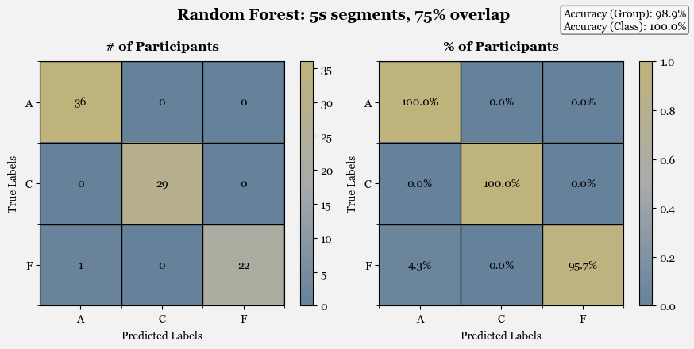

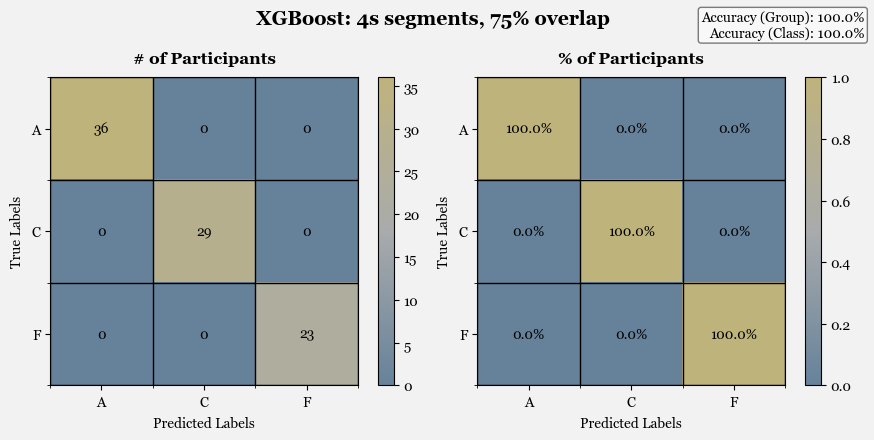

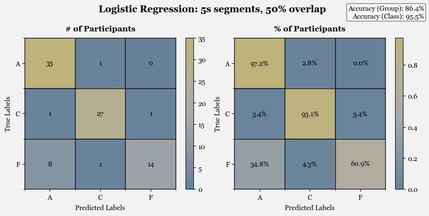

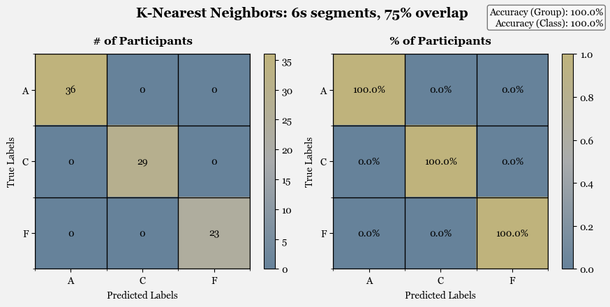

```python
for k, v in dataset_use.items():
    model_name = MODEL_ALIAS[k]
    tmp_seg = int(v.split('_')[0])/1000
    tmp_ovl = int(v.split('_')[1])/100
    tmp_results = results[k][v].copy()

    tmp_fig = generate_heatmap(
        tmp_results['scores']['TruthValues'],
        tmp_results['scores']['PredictedValues'],
        tmp_results['encoder'],
        accs = [tmp_results['scores']["Accuracy_Group"], tmp_results['scores']["Accuracy_Class"]],
        title = f'{model_name}: {tmp_seg:.0f}s segments, {tmp_ovl:.0%} overlap',
    )

    #save figure to file
    tmp_fig.savefig(f'figs/basis_{k}_cm.png', dpi=300, bbox_inches='tight')
    display(tmp_fig)
```

# Model Hyperparameter Tuning

## Define Dataset for Each Model

```python
debug_mode = True

model_datasets = {}
for k,v in dataset_use.items():
    model_datasets[k] = epochs[v].copy()

rf_tune_data = model_datasets['RF']
xgb_tune_data = model_datasets['XGB']
lr_tune_data = model_datasets['LR']
knn_tune_data = model_datasets['KNN']

def param_combos(params):
    for instance in product(*params.values()):
        yield dict(zip(params.keys(), instance))
```

## Random Forest Tuning

```python
rf_params = {
    'n_estimators': [100, 200, 300, 400],
    'max_depth': [None, 10, 20, 30, 40],
    'min_samples_split': [2, 5, 10],
    'min_samples_leaf': [1, 2, 4],
    'bootstrap': [True, False],
    'max_features': ['auto', 'sqrt', 'log2'],
}

rf_params_iter = list(param_combos(rf_params))
if len(rf_params_iter) > 2:
    print(f'{len(rf_params_iter)} Parameter combinations exceeds {2} limit - reducing to random sample of {2}')
    import random
    random.seed(SEED_VAL)
    rf_params_iter = random.sample(rf_params_iter, 2)

rf_labeled = add_labels(rf_tune_data, participants, label_encoder)

rf_kf = KFold(n_splits=NFOLDS, shuffle=True, random_state=SEED_VAL)

rf_features = rf_labeled[[i for i in rf_labeled.columns if i.endswith('_rbp')]]
rf_labels = rf_labeled['Group_encoded']

rf_kfold_results = {'params_tested': rf_params_iter}
s_modeling = default_timer()
for c_p, param_set in enumerate(rf_params_iter):
    s_params = default_timer()
    c_k = 0
    # for train_idx, test_idx in rf_kf.split(rf_features):
```

```
1080 Parameter combinations exceeds 2 limit - reducing to random sample of 2
```

```python
for train_idx, test_idx in rf_kf.split(rf_features):
    print(train_idx, test_idx)
    print(rf_features.iloc[train_idx].shape, rf_features.iloc[test_idx].shape)
```

```
[    0     1     2 ... 55906 55907 55908] [   22    33    35 ... 55890 55897 55905]
(44727, 95) (11182, 95)
[    2     3     4 ... 55905 55906 55908] [    0     1    12 ... 55886 55902 55907]
(44727, 95) (11182, 95)
[    0     1     2 ... 55906 55907 55908] [    4     5     7 ... 55892 55893 55900]
(44727, 95) (11182, 95)
[    0     1     2 ... 55906 55907 55908] [    6    10    16 ... 55895 55903 55904]
(44727, 95) (11182, 95)
[    0     1     4 ... 55904 55905 55907] [    2     3    17 ... 55901 55906 55908]
(44728, 95) (11181, 95)
```

```python
rf_params = {
    'n_estimators': [100, 200, 300, 400],
    'max_depth': [None, 10, 20, 30, 40],
    'min_samples_split': [2, 5, 10],
    'min_samples_leaf': [1, 2, 4],
    'bootstrap': [True, False],
    'max_features': ['auto', 'sqrt', 'log2'],
}

rf_params_iter = list(param_combos(rf_params))
if len(rf_params_iter) > MAX_PARAMS:
    print(f'{len(rf_params_iter)} Parameter combinations exceeds {MAX_PARAMS} limit - reducing to random sample of {MAX_PARAMS}')
    import random
    random.seed(SEED_VAL)
    rf_params_iter = random.sample(rf_params_iter, MAX_PARAMS)

rf_labeled = add_labels(rf_tune_data, participants, label_encoder)

rf_kf = KFold(n_splits=NFOLDS, shuffle=True, random_state=SEED_VAL)

rf_features = rf_labeled[[i for i in rf_labeled.columns if i.endswith('_rbp')]]
rf_labels = rf_labeled['Group_encoded']

rf_kfold_results = {'params_tested': rf_params_iter}
s_modeling = default_timer()
for c_p, param_set in enumerate(rf_params_iter):
    s_params = default_timer()
    c_k = 0
    for train_idx, test_idx in rf_kf.split(rf_features):
        x_train, x_test = rf_features.iloc[train_idx], rf_features.iloc[test_idx]
        y_train, y_test = rf_labels.iloc[train_idx], rf_labels.iloc[test_idx]
        pid_test = rf_labeled.iloc[test_idx]['participant_id']

        tmp_model = RandomForestClassifier(random_state=SEED_VAL, n_jobs= -1, **param_set)
        tmp_model.fit(x_train, y_train)

        y_pred = tmp_model.predict(x_test)
        y_pred_group = label_encoder.inverse_transform(y_pred)
        y_pred_class = np.array([PARTICIPANT_CLASS_MAP[x] for x in y_pred_group])
        rf_kfold_results[(c_p, c_k)] = {
            # 'model': tmp_model,
            # 'encoder': label_encoder,
            'scores': score_model(pid_test, y_pred_group, participants, label_encoder, False)
        }

        c_k += 1

    if debug_mode: print(f'Parameter set {c_p+1}/{len(rf_params_iter)} Finished.', format_timing(default_timer() - s_params))
printmd('---')
printmd(f'# All Random Forest Models built. | Total Time: {format_timing(default_timer() - s_modeling)}')
```

```
1080 Parameter combinations exceeds 100 limit - reducing to random sample of 100
Parameter set 1/100 Finished. 0:01:21.752335
Parameter set 2/100 Finished. 0:01:22.789676
Parameter set 3/100 Finished. 0:00:31.252919
Parameter set 4/100 Finished. 0:00:15.200541
Parameter set 5/100 Finished. 0:01:04.379666
Parameter set 6/100 Finished. 0:01:05.430056
Parameter set 7/100 Finished. 0:00:23.285259
Parameter set 8/100 Finished. 0:00:24.018077
Parameter set 9/100 Finished. 0:00:43.028662
Parameter set 10/100 Finished. 0:00:41.878962
Parameter set 11/100 Finished. 0:01:05.590856
Parameter set 12/100 Finished. 0:00:41.394412
Parameter set 13/100 Finished. 0:00:15.626840
Parameter set 14/100 Finished. 0:00:15.830272
Parameter set 15/100 Finished. 0:01:22.684775
Parameter set 16/100 Finished. 0:00:59.400585
Parameter set 17/100 Finished. 0:00:55.864858
Parameter set 18/100 Finished. 0:00:20.600895
Parameter set 19/100 Finished. 0:00:22.254416
Parameter set 20/100 Finished. 0:01:01.484867
Parameter set 21/100 Finished. 0:00:27.320357
Parameter set 22/100 Finished. 0:01:04.243550
Parameter set 23/100 Finished. 0:00:42.556551
Parameter set 24/100 Finished. 0:00:41.447802
Parameter set 25/100 Finished. 0:01:24.732720
Parameter set 26/100 Finished. 0:00:54.069140
Parameter set 27/100 Finished. 0:00:28.023150
Parameter set 28/100 Finished. 0:00:22.468708
Parameter set 29/100 Finished. 0:00:28.053327
Parameter set 30/100 Finished. 0:00:22.746764
Parameter set 31/100 Finished. 0:00:22.928662
Parameter set 32/100 Finished. 0:01:18.410800
Parameter set 33/100 Finished. 0:00:21.127908
Parameter set 34/100 Finished. 0:00:40.712954
Parameter set 35/100 Finished. 0:00:58.048642
Parameter set 36/100 Finished. 0:00:10.366253
Parameter set 37/100 Finished. 0:00:42.232410
Parameter set 38/100 Finished. 0:00:15.424444
Parameter set 39/100 Finished. 0:00:14.571868
```

[output cut: 46 more lines]

```
Parameter set 86/100 Finished. 0:00:15.362637
Parameter set 87/100 Finished. 0:00:16.174511
Parameter set 88/100 Finished. 0:01:02.929731
Parameter set 89/100 Finished. 0:00:41.889627
Parameter set 90/100 Finished. 0:01:23.500452
Parameter set 91/100 Finished. 0:00:43.442869
Parameter set 92/100 Finished. 0:01:24.289243
Parameter set 93/100 Finished. 0:00:39.730187
Parameter set 94/100 Finished. 0:00:40.194905
Parameter set 95/100 Finished. 0:01:20.060745
Parameter set 96/100 Finished. 0:00:41.671229
Parameter set 97/100 Finished. 0:01:05.095994
Parameter set 98/100 Finished. 0:00:58.605922
Parameter set 99/100 Finished. 0:00:27.781988
Parameter set 100/100 Finished. 0:00:44.443393
```

All Random Forest Models built. | Total Time: 1:17:43.188445

## XGBoost Tuning

```python
xgb_params = {
    'n_estimators': [100, 200, 300],
    'learning_rate': [0.01, 0.1, 0.2],
    'max_depth': [3, 6, 9],
    'min_child_weight': [1, 3, 5],
    'subsample': [0.7, 0.8, 0.9],
    'colsample_bytree': [0.7, 0.8, 0.9],
}

xgb_params_iter = list(param_combos(xgb_params))
if len(xgb_params_iter) > MAX_PARAMS:
    print(f'{len(xgb_params_iter)} Parameter combinations exceeds {MAX_PARAMS} limit - reducing to random sample of {MAX_PARAMS}')
    import random
    random.seed(SEED_VAL)
    xgb_params_iter = random.sample(xgb_params_iter, MAX_PARAMS)

xgb_labeled = add_labels(xgb_tune_data, participants, label_encoder)

xgb_kf = KFold(n_splits=NFOLDS, shuffle=True, random_state=SEED_VAL)

xgb_features = xgb_labeled[[i for i in xgb_labeled.columns if i.endswith('_rbp')]]
xgb_labels = xgb_labeled['Group_encoded']

xgb_kfold_results = {'params_tested': xgb_params_iter}
s_modeling = default_timer()
for c_p, param_set in enumerate(xgb_params_iter):
    s_params = default_timer()
    c_k = 0
    for train_idx, test_idx in xgb_kf.split(xgb_features):
        x_train, x_test = xgb_features.iloc[train_idx], xgb_features.iloc[test_idx]
        y_train, y_test = xgb_labels.iloc[train_idx], xgb_labels.iloc[test_idx]
        pid_test = xgb_labeled.iloc[test_idx]['participant_id']

        tmp_model = XGBClassifier(random_state=SEED_VAL, n_jobs= -1, **param_set)
        tmp_model.fit(x_train, y_train)

        y_pred = tmp_model.predict(x_test)
        y_pred_group = label_encoder.inverse_transform(y_pred)
        y_pred_class = np.array([PARTICIPANT_CLASS_MAP[x] for x in y_pred_group])
        xgb_kfold_results[(c_p, c_k)] = {
            # 'model': tmp_model,
            # 'encoder': label_encoder,
            'scores': score_model(pid_test, y_pred_group, participants, label_encoder, False)
        }

        c_k += 1

    if debug_mode: print(f'Parameter set {c_p+1}/{len(xgb_params_iter)} Finished.', format_timing(default_timer() - s_params))
printmd('---')
printmd(f'# All Logistic Regression Models built. | Total Time: {format_timing(default_timer() - s_modeling)}')
```

```
729 Parameter combinations exceeds 100 limit - reducing to random sample of 100
Parameter set 1/100 Finished. 0:00:14.523374
Parameter set 2/100 Finished. 0:00:49.066771
Parameter set 3/100 Finished. 0:00:41.317406
Parameter set 4/100 Finished. 0:00:58.596819
Parameter set 5/100 Finished. 0:00:38.817286
Parameter set 6/100 Finished. 0:00:35.396093
Parameter set 7/100 Finished. 0:01:33.801948
Parameter set 8/100 Finished. 0:00:08.902206
Parameter set 9/100 Finished. 0:00:57.090957
Parameter set 10/100 Finished. 0:00:30.769892
Parameter set 11/100 Finished. 0:00:08.613736
Parameter set 12/100 Finished. 0:00:08.137657
Parameter set 13/100 Finished. 0:00:16.513963
Parameter set 14/100 Finished. 0:01:10.762655
Parameter set 15/100 Finished. 0:01:08.870299
Parameter set 16/100 Finished. 0:00:39.755358
Parameter set 17/100 Finished. 0:02:02.715099
Parameter set 18/100 Finished. 0:00:09.220446
Parameter set 19/100 Finished. 0:00:15.532835
Parameter set 20/100 Finished. 0:00:23.524294
Parameter set 21/100 Finished. 0:00:42.737322
Parameter set 22/100 Finished. 0:01:18.969325
Parameter set 23/100 Finished. 0:00:50.370710
Parameter set 24/100 Finished. 0:00:58.938908
Parameter set 25/100 Finished. 0:00:15.632539
Parameter set 26/100 Finished. 0:00:42.845552
Parameter set 27/100 Finished. 0:00:08.758982
Parameter set 28/100 Finished. 0:00:16.887023
Parameter set 29/100 Finished. 0:00:33.656723
Parameter set 30/100 Finished. 0:00:28.873878
Parameter set 31/100 Finished. 0:01:17.287200
Parameter set 32/100 Finished. 0:00:17.268641
Parameter set 33/100 Finished. 0:00:15.665869
Parameter set 34/100 Finished. 0:00:46.862697
Parameter set 35/100 Finished. 0:00:08.198127
Parameter set 36/100 Finished. 0:02:01.260150
Parameter set 37/100 Finished. 0:00:16.261890
Parameter set 38/100 Finished. 0:00:36.031738
Parameter set 39/100 Finished. 0:01:02.671684
```

[output cut: 46 more lines]

```
Parameter set 86/100 Finished. 0:00:22.627649
Parameter set 87/100 Finished. 0:00:22.048056
Parameter set 88/100 Finished. 0:00:31.060282
Parameter set 89/100 Finished. 0:00:26.393460
Parameter set 90/100 Finished. 0:00:32.177407
Parameter set 91/100 Finished. 0:00:22.099529
Parameter set 92/100 Finished. 0:00:15.212228
Parameter set 93/100 Finished. 0:00:30.693845
Parameter set 94/100 Finished. 0:01:22.016398
Parameter set 95/100 Finished. 0:01:28.343877
Parameter set 96/100 Finished. 0:00:36.535001
Parameter set 97/100 Finished. 0:00:18.063621
Parameter set 98/100 Finished. 0:01:20.435853
Parameter set 99/100 Finished. 0:00:31.243165
Parameter set 100/100 Finished. 0:00:23.761282
```

All Logistic Regression Models built. | Total Time: 1:04:52.941560

## Logistic Regression

```python
lr_params = {
    'C': [0.001, 0.01, 0.1, 1, 10, 100],
    'solver': ['newton-cg', 'lbfgs', 'sag', 'saga'],
    'max_iter': [100, 200, 300],
    'penalty': ['l2', None],
    'l1_ratio': [None, 0.5],
}

lr_params_iter = list(param_combos(lr_params))
if len(lr_params_iter) > MAX_PARAMS:
    print(f'{len(lr_params_iter)} Parameter combinations exceeds {MAX_PARAMS} limit - reducing to random sample of {MAX_PARAMS}')
    import random
    random.seed(SEED_VAL)
    lr_params_iter = random.sample(lr_params_iter, MAX_PARAMS)

lr_labeled = add_labels(lr_tune_data, participants, label_encoder)

lr_kf = KFold(n_splits=NFOLDS, shuffle=True, random_state=SEED_VAL)

lr_features = lr_labeled[[i for i in lr_labeled.columns if i.endswith('_rbp')]]
lr_labels = lr_labeled['Group_encoded']

lr_kfold_results = {'params_tested': lr_params_iter}
s_modeling = default_timer()
for c_p, param_set in enumerate(lr_params_iter):
    s_params = default_timer()
    c_k = 0
    for train_idx, test_idx in lr_kf.split(lr_features):
        x_train, x_test = lr_features.iloc[train_idx], lr_features.iloc[test_idx]
        y_train, y_test = lr_labels.iloc[train_idx], lr_labels.iloc[test_idx]
        pid_test = lr_labeled.iloc[test_idx]['participant_id']

        tmp_model = LogisticRegression(random_state=SEED_VAL, n_jobs= -1, **param_set)
        tmp_model.fit(x_train, y_train)

        y_pred = tmp_model.predict(x_test)
        y_pred_group = label_encoder.inverse_transform(y_pred)
        y_pred_class = np.array([PARTICIPANT_CLASS_MAP[x] for x in y_pred_group])
        lr_kfold_results[(c_p, c_k)] = {
            # 'model': tmp_model,
            # 'encoder': label_encoder,
            'scores': score_model(pid_test, y_pred_group, participants, label_encoder, False)
        }

        c_k += 1

    if debug_mode: print(f'Parameter set {c_p+1}/{len(lr_params_iter)} Finished.', format_timing(default_timer() - s_params))
printmd('---')
printmd(f'# All Logistic Regression Models built. | Total Time: {format_timing(default_timer() - s_modeling)}')
```

```
288 Parameter combinations exceeds 100 limit - reducing to random sample of 100
Parameter set 1/100 Finished. 0:00:12.015380
Parameter set 2/100 Finished. 0:00:37.219430
Parameter set 3/100 Finished. 0:00:06.340420
Parameter set 4/100 Finished. 0:00:05.223587
Parameter set 5/100 Finished. 0:00:12.138404
Parameter set 6/100 Finished. 0:00:12.962321
Parameter set 7/100 Finished. 0:00:04.497915
Parameter set 8/100 Finished. 0:00:02.821742
Parameter set 9/100 Finished. 0:00:26.242074
Parameter set 10/100 Finished. 0:00:24.453119
Parameter set 11/100 Finished. 0:00:07.585499
Parameter set 12/100 Finished. 0:00:10.762102
Parameter set 13/100 Finished. 0:00:14.337706
Parameter set 14/100 Finished. 0:00:14.740529
Parameter set 15/100 Finished. 0:00:24.692547
Parameter set 16/100 Finished. 0:00:08.734138
Parameter set 17/100 Finished. 0:00:06.870868
Parameter set 18/100 Finished. 0:00:17.635143
Parameter set 19/100 Finished. 0:00:24.331023
Parameter set 20/100 Finished. 0:00:10.398427
Parameter set 21/100 Finished. 0:00:01.234735
Parameter set 22/100 Finished. 0:00:12.597164
Parameter set 23/100 Finished. 0:00:04.244613
Parameter set 24/100 Finished. 0:00:12.560399
Parameter set 25/100 Finished. 0:00:07.021113
Parameter set 26/100 Finished. 0:00:02.511497
Parameter set 27/100 Finished. 0:00:06.788247
Parameter set 28/100 Finished. 0:00:08.956939
Parameter set 29/100 Finished. 0:00:14.635938
Parameter set 30/100 Finished. 0:00:37.176801
Parameter set 31/100 Finished. 0:00:08.476367
Parameter set 32/100 Finished. 0:00:24.275547
Parameter set 33/100 Finished. 0:00:14.691745
Parameter set 34/100 Finished. 0:00:08.931114
Parameter set 35/100 Finished. 0:00:11.327435
Parameter set 36/100 Finished. 0:00:12.571229
Parameter set 37/100 Finished. 0:00:01.756066
Parameter set 38/100 Finished. 0:00:14.529934
Parameter set 39/100 Finished. 0:00:14.618378
```

[output cut: 46 more lines]

```
Parameter set 86/100 Finished. 0:00:01.726026
Parameter set 87/100 Finished. 0:00:06.777105
Parameter set 88/100 Finished. 0:00:14.917069
Parameter set 89/100 Finished. 0:00:27.140854
Parameter set 90/100 Finished. 0:00:08.338933
Parameter set 91/100 Finished. 0:00:26.022805
Parameter set 92/100 Finished. 0:00:08.986961
Parameter set 93/100 Finished. 0:00:10.274703
Parameter set 94/100 Finished. 0:00:06.915968
Parameter set 95/100 Finished. 0:00:08.942147
Parameter set 96/100 Finished. 0:00:17.734114
Parameter set 97/100 Finished. 0:00:08.482827
Parameter set 98/100 Finished. 0:00:03.361191
Parameter set 99/100 Finished. 0:00:01.338512
Parameter set 100/100 Finished. 0:00:06.891830
```

All Logistic Regression Models built. | Total Time: 0:20:13.187613

## K-Nearest Neighbor Tuning

```python
knn_params = {
    'n_neighbors': [3, 5, 7, 10, 15],
    'weights': ['uniform', 'distance'],
    'metric': ['euclidean', 'manhattan', 'minkowski'],
    'algorithm': ['auto', 'ball_tree', 'kd_tree', 'brute'],
    'leaf_size': [10, 30, 50],
}

knn_params_iter = list(param_combos(knn_params))
if len(knn_params_iter) > MAX_PARAMS:
    print(f'{len(knn_params_iter)} Parameter combinations exceeds {MAX_PARAMS} limit - reducing to random sample of {MAX_PARAMS}')
    import random
    random.seed(SEED_VAL)
    knn_params_iter = random.sample(knn_params_iter, MAX_PARAMS)

knn_labeled = add_labels(knn_tune_data, participants, label_encoder)

knn_kf = KFold(n_splits=NFOLDS, shuffle=True, random_state=SEED_VAL)

knn_features = knn_labeled[[i for i in knn_labeled.columns if i.endswith('_rbp')]]
knn_labels = knn_labeled['Group_encoded']

knn_kfold_results = {'params_tested': knn_params_iter}
s_modeling = default_timer()
for c_p, param_set in enumerate(knn_params_iter):
    s_params = default_timer()
    c_k = 0
    for train_idx, test_idx in knn_kf.split(knn_features):
        x_train, x_test = knn_features.iloc[train_idx], knn_features.iloc[test_idx]
        y_train, y_test = knn_labels.iloc[train_idx], knn_labels.iloc[test_idx]
        pid_test = knn_labeled.iloc[test_idx]['participant_id']

        tmp_model = KNeighborsClassifier(n_jobs=-1, **param_set)
        tmp_model.fit(x_train, y_train)

        y_pred = tmp_model.predict(x_test)
        y_pred_group = label_encoder.inverse_transform(y_pred)
        y_pred_class = np.array([PARTICIPANT_CLASS_MAP[x] for x in y_pred_group])
        knn_kfold_results[(c_p, c_k)] = {
            # 'model': tmp_model,
            # 'encoder': label_encoder,
            'scores': score_model(pid_test, y_pred_group, participants, label_encoder, False)
        }

        c_k += 1

    if debug_mode: print(f'Parameter set {c_p+1}/{len(knn_params_iter)} Finished.', format_timing(default_timer() - s_params))
printmd('---')
printmd(f'# All K-Nearest Neighbors Models built. | Total Time: {format_timing(default_timer() - s_modeling)}')
```

```
360 Parameter combinations exceeds 100 limit - reducing to random sample of 100
Parameter set 1/100 Finished. 0:00:02.057494
Parameter set 2/100 Finished. 0:00:32.315123
Parameter set 3/100 Finished. 0:00:39.136863
Parameter set 4/100 Finished. 0:00:02.474817
Parameter set 5/100 Finished. 0:00:11.946869
Parameter set 6/100 Finished. 0:00:02.299429
Parameter set 7/100 Finished. 0:00:03.399499
Parameter set 8/100 Finished. 0:00:11.915560
Parameter set 9/100 Finished. 0:00:11.297674
Parameter set 10/100 Finished. 0:00:30.325629
Parameter set 11/100 Finished. 0:00:03.182438
Parameter set 12/100 Finished. 0:00:02.213751
Parameter set 13/100 Finished. 0:00:11.054659
Parameter set 14/100 Finished. 0:00:32.371150
Parameter set 15/100 Finished. 0:00:02.192251
Parameter set 16/100 Finished. 0:00:02.331599
Parameter set 17/100 Finished. 0:00:02.412683
Parameter set 18/100 Finished. 0:00:16.992114
Parameter set 19/100 Finished. 0:00:11.142987
Parameter set 20/100 Finished. 0:00:38.683509
Parameter set 21/100 Finished. 0:00:34.560112
Parameter set 22/100 Finished. 0:00:28.669744
Parameter set 23/100 Finished. 0:00:35.178678
Parameter set 24/100 Finished. 0:00:02.448257
Parameter set 25/100 Finished. 0:00:15.934329
Parameter set 26/100 Finished. 0:00:14.880729
Parameter set 27/100 Finished. 0:00:35.832016
Parameter set 28/100 Finished. 0:00:19.841661
Parameter set 29/100 Finished. 0:00:02.255616
Parameter set 30/100 Finished. 0:00:03.297942
Parameter set 31/100 Finished. 0:00:11.214074
Parameter set 32/100 Finished. 0:00:02.366673
Parameter set 33/100 Finished. 0:00:11.343745
Parameter set 34/100 Finished. 0:00:12.028568
Parameter set 35/100 Finished. 0:00:02.204007
Parameter set 36/100 Finished. 0:00:02.136887
Parameter set 37/100 Finished. 0:00:31.909061
Parameter set 38/100 Finished. 0:00:11.201468
Parameter set 39/100 Finished. 0:00:03.236815
```

[output cut: 46 more lines]

```
Parameter set 86/100 Finished. 0:00:37.208527
Parameter set 87/100 Finished. 0:00:36.681740
Parameter set 88/100 Finished. 0:00:16.283155
Parameter set 89/100 Finished. 0:00:19.763039
Parameter set 90/100 Finished. 0:00:03.202594
Parameter set 91/100 Finished. 0:00:34.380594
Parameter set 92/100 Finished. 0:00:02.289527
Parameter set 93/100 Finished. 0:00:02.483540
Parameter set 94/100 Finished. 0:00:31.489403
Parameter set 95/100 Finished. 0:00:31.579508
Parameter set 96/100 Finished. 0:00:02.178668
Parameter set 97/100 Finished. 0:00:12.315064
Parameter set 98/100 Finished. 0:00:03.174739
Parameter set 99/100 Finished. 0:00:26.243204
Parameter set 100/100 Finished. 0:00:12.146499
```

All K-Nearest Neighbors Models built. | Total Time: 0:27:02.663895

# Export Hyperparameter Results

```python
all_kfold_results = {
    'RF': rf_kfold_results,
    'XGB': xgb_kfold_results,
    'LR': lr_kfold_results,
    'KNN': knn_kfold_results,
}

with open('data/TunedModelResults.pkl', 'wb') as f:
    pickle.dump(all_kfold_results, f)
print('Results saved to data/TunedModelResults.pkl')
```

```
Results saved to data/TunedModelResults.pkl
```

# Export Source Code

```python
user = str(pathlib.Path.home()).split('\\')[-1]
export_flag = False
if user != 'bkeith' and user != 'Brian':
    raise Exception('User running code is not the student. No need to run below.')
else:
    export_flag = True
    print('User running code is the student. Continue to file Export.')

cur_file = __vsc_ipynb_file__
output_dir = 'zlogs'
output_name = cur_file.split('\\')[-1].split('.')[0] + f'.html'
cell_tags_exist = False
template = 'classic'

if export_flag == True:
    export_code(cur_file,output_dir, output_name, cell_tags_exist, template=template)
```

```
User running code is the student. Continue to file Export.
```